# Final Poster

Deane de Menezes

12/22/2021

Library and Data

```r
rm(list = ls())
library(igraph)
library(migraph) #Version 0.8.13
library(RSiena)
```

## Including Plots

Kapferer Tailor Shop Network

# INTRODUCTION

Bruce Kapferer, an Australian anthropologist, observed interactions in a tailor shop in Zambia over a period of ten months in 1965. He tracked the development of a strike at the tailor shop and his focus was the changing patterns of alliance among workers during extended negotiations for higher wages.

The data were collected by continuous direct observation between June 1965 and February 1966. This data was further divided into two transactions: instrumental (work) and sociational (social). • Instrumental (Work): Transactions like lending or giving of money, assistance at times of personal crisis, help at work. These transactions are asymmetric since they lead to a debt of obligation between actors and hence creates prestige and status among them. This is a directed network.

# DATA SUMMARY

The networks have :- 39 individuals(nodes) 2 waves 1 attribute which is the job status of each of the 39 workers.

# DATA PROCESSING

Loading the data and converting it to matrix form

```r
work_1 <- read.table("kapfti1.dat")
work_2 <- read.table("kapfti2.dat")
soc_1 <- read.table("kapfts1.dat")
soc_2 <- read.table("kapfts2.dat")
job_status <- read.table("kapfa_stat.dat")

work_1_m <- as.matrix(work_1)
work_2_m <- as.matrix(work_2)
soc_1_m <- as.matrix(soc_1)
soc_2_m <- as.matrix(soc_2)
job_status_m<- as.matrix(job_status)
```

# RESEARCH QUESTION AND HYPOTHESES

This research is interested in the how relationships are built in the workplace and how hierarchy comes to play in the creation of such ties. While individuals typically decide who they choose to be friends with, in a workplace environment, one does not have control over such factors (Sais et al, 2003) and this was the background as I framed my research question. According to Kokkonen (2012), frequent exposure to another person during work hours/work related tasks fosters more interactions and results in a higher chance of developing a friendship a the workplace.

The main research question is: Does the job status make a difference when we make friends at work?

The hypothesis is:

H1: Tailor workers with a higher job status have a low chance of becoming friends (forming social ties) with other team members

For this poster, we will only be looking at social ties network data and not the instrumental(work) ties.

# VISUALIZATION OF THE NETWORK

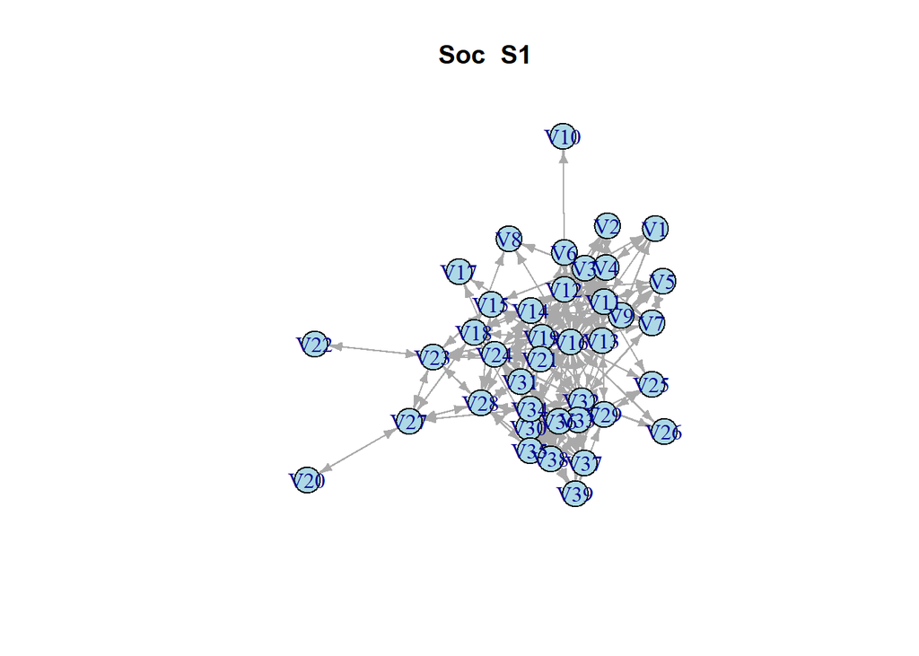

```r
graph3 <- graph.adjacency(soc_1_m, mode="directed")
graph4 <- graph.adjacency(soc_2_m, mode="directed")
plot(graph3, main="Soc  S1", edge.arrow.size=0.5, vertex.size = 15, vertex.color = "lightblue")
```

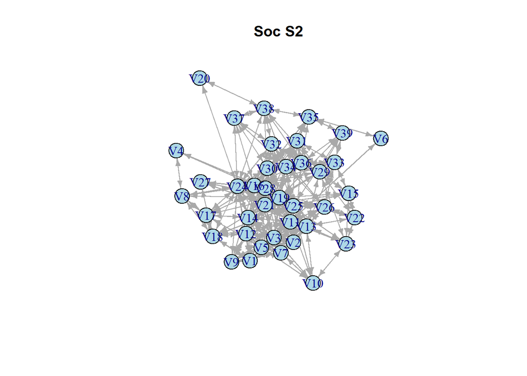

```r
plot(graph4, main="Soc S2",edge.arrow.size=0.5, vertex.size = 15, vertex.color = "lightblue")
```

# MODELLING APPROACH

```r
library(RSiena)
social<- sienaDependent(array(c(soc_1_m, soc_2_m), dim = c(39, 39, 2) ),

                        type="oneMode")
typeof(job_status)
```

```
## [1] "list"
```

```r
job_l <- unlist(job_status)
job_l
```

```
##  V11  V12  V13  V14  V15  V16  V17  V18  V19 V110 V111 V112 V113 V114 V115 V116
##    3    3    3    8    3    3    3    5    3    8    3    3    3    3    5    2
## V117 V118 V119 V120 V121 V122 V123 V124 V125 V126 V127 V128 V129 V130 V131 V132
##    8    8    1    5    3    5    5    3    4    4    5    5    6    7    7    7
## V133 V134 V135 V136 V137 V138 V139
##    6    7    7    7    7    7    6
```

```r
jobstatus<- coCovar(job_l)
KapfererData <- sienaDataCreate(social,
                              jobstatus)
print01Report(KapfererData, modelname = 'KapfererResults')
```

# EFFECTS

```r
Kapeff <- getEffects(KapfererData)

Kapeff
```

```
##   effectName                  include fix   test  initialValue parm
## 1 basic rate parameter social TRUE    FALSE FALSE   18.40674   0
## 2 degree (density)            TRUE    FALSE FALSE   -0.26272   0
```

```r
effectsDocumentation(Kapeff, type="html", display = T)

Kapeff <- setEffect(Kapeff, transTriads, include=FALSE)
```

```
## [1] effectName   include      fix          test         initialValue
## [6] parm
## <0 rows> (or 0-length row.names)
```

```r
Kapeff <- includeEffects(Kapeff, nbrDist2)
```

```
##   effectName                      include fix   test  initialValue parm
## 1 number of actor pairs at dist 2 TRUE    FALSE FALSE          0   0
```

```r
Kapeff
```

```
##   effectName                      include fix   test  initialValue parm
## 1 basic rate parameter social     TRUE    FALSE FALSE   18.40674   0
## 2 degree (density)                TRUE    FALSE FALSE   -0.26272   0
## 3 number of actor pairs at dist 2 TRUE    FALSE FALSE    0.00000   0
```

# SIENA MODEL

```r
model33 <- sienaAlgorithmCreate(projname = "KapfererResults",
                            modelType = c(social=3), cond=F,  n3=1000)
```

```
## If you use this algorithm object, siena07 will create/use an output file KapfererResults.txt .
```

```r
ans1 <- siena07(model33, data = KapfererData , effects = Kapeff)
ans1
```

```
## Estimates, standard errors and convergence t-ratios
##
##                                           Estimate   Standard   Convergence
##                                                        Error      t-ratio
##   1. rate basic rate parameter social      7.3509  ( 0.8003   )    0.0120
##   2. eval degree (density)                -0.3025  ( 0.0682   )   -0.0379
##   3. eval number of actor pairs at dist 2 -0.2537  ( 0.0632   )   -0.1058
##
## Overall maximum convergence ratio:    0.1226
##
##
##  Model Type:
## social : Initiative model
##
##
## Total of 2267 iteration steps.
```

```r
siena.table(ans1)
xtable(ans1, type = "html", file = "results.html")
```

# CONCLUSIONS AND LIMITATIONS

The key limitations are that apart from job status of the 39 workers, it did not capture other attributes like previous work experience, sex, years left to retirement, age etc. Further, in this dataset, there were 2 worker strikes which took place during the course of the data collection (Kapferer, 1972). The first episode was a strike which was thwarted shortly after the the first set of observations were recorded and the second successful strike was after the second set of observations.The power shifts among the 39 workers between these 2 strikes have been missed out in this analysis and would be interesting to explore in further studies.

# BIBLIOGRAPHY

Kapferer B. (1972). Strategy and transaction in an African factory. Manchester: Machester University Press

Kokkonen, Andrej (2012) “Integrating Potential of Diverse Workplaces.” In APSA 2012 Annual Meeting Paper.

Ripley, Ruth M., Snijders, Tom A.B., and Preciado Paulina 2011, Manual for SIENA Ruth Ripley, Tom A.B. Snijders, Zsófia Boda, Andras Vörös, and Paulina Preciado (2017). Manual for SIENA version 4.0. Oxford: University of Oxford, Department of Statistics, http://www.stats.ox.ac.uk/~snijders/siena/.

Sias, P.M., Smith, G. and Avdeyeva, T.2003. Sex and Sex Composition Differences and Similarities in Peer Workplace Friendship Development. Communication Studies,54: 322-40.

Snijders, Tom A B, Gerhard G Van de Bunt, and Christian E G Steglich. 2010. “Introduction to Stochastic Actor-Based Models for Network Dynamics.” Social Networks 32 (1): 44-60.

Tom A.B. Snijders (2001) The statistical evaluation of social network dynamics, Sociological Methodology - 2001, 40: 361-395.